# Ensambles - Clase 1

# El problema

La clase pasada, cerramos viendo que los árboles de decisión presentan algunos pros y varios contras. Si bien son modelos muy interpretables y sencillos de explicar, no tienen mucha potencia en capacidad predictiva. Esto se debe a que:

- son bastante simples, y pueden tender al overfit.
- Su enfoque greedy y top to bottom hace que se concentren siempre en buscar óptimos locales, no globales.

Sin embargo, existen formas de **ensamblar** varios árboles para superar estas limitaciones y hacer modelos más potentes. La clase de hoy vamos a ver cómo implementamos un modelo de **bagging** en `tidymodels`.

Estábamos trabajando con los resultados de la ENUT 2021, y buscamos predecir si las personas encuestadas realizan trabajo doméstico o no. Creamos una variable ad-hoc llamada `realiza_domest`, y definimos que si las personas dedican menos de 60 minutos al día en hacer TD, entran en la categoría de “No realiza”. Más de eso, entran en la categoría “Realiza”.

```r
library(tidyverse)

data <- read_delim("./data/enut2021_base.txt", delim = "|")

data <- data %>% select(ID, SEXO_SEL, EDAD_SEL, TCS_GRUPO_DOMESTICO, CONDICION_ACTIVIDAD_AGRUPADA,
                        NIVEL_EDUCATIVO_AGRUPADO, CANT_DEMANDANTES_TOTAL, CANT_NODEMANDANTES_TOTAL,
                        BHCH04_SEL, BHDC_SEL) %>%
  mutate(realiza_domest = as.factor(case_when(
    TCS_GRUPO_DOMESTICO > 60 ~ "Realiza",
    TRUE ~ "No realiza")))

data <- data %>% mutate_at(
                   vars(SEXO_SEL),
                    ~as.factor(case_when(
                      . == 1 ~ "Mujer",
                      . == 2 ~ "Varón"
                    )))



data <- data %>% mutate_at(vars(CONDICION_ACTIVIDAD_AGRUPADA),
                   ~as.factor(case_when(
                     . == 1 ~ "Ocupado",
                     . == 2 ~ "No ocupado"
                   )))

data <- data %>% mutate_at(vars(BHCH04_SEL),
                   ~as.factor(case_when(
                     . == 1 ~ "Jefe/a",
                     . == 2 ~ "Cónyuge/pareja",
                     . == 3 ~ "Hijo/a",
                     . == 4 ~ "Hijastro/a",
                     . == 5 ~ "Yerno/nuera",
                     . == 6 ~ "Nieto/a",
                     . == 7 ~ "Padre o madre",
                     . == 8 ~ "Suegro/a",
                     . == 9 ~ "Hermano/a",
                     . == 10 ~ "Cuñado/a",
                     . == 11 ~ "Sobrino/a",
                     . == 12 ~ "Abuelo/a",
                     . == 13 ~ "Otro familiar",
                     . == 14 ~ "Otro no familiar")))



 data <- data %>% mutate_at(vars(BHDC_SEL),
                   ~as.factor(case_when(
                     . == 0 ~ "No es demandante de cuidado",
                     . == 1 ~ "Es demandante de cuidado"
                   )))

data<- data %>% select(-TCS_GRUPO_DOMESTICO)
```

# Árbol simple

Refresquemos el modelo de clase previa. Lo podemos importar como RDS.

```r
test_dt_simple <- readRDS('../data/validation_test_dt.RDS')
```

¿Cómo funcionaba?

```r
class_metrics_dt <- metric_set(precision, recall,
                       accuracy, f_meas)

class_metrics_dt(test_dt_simple, truth = realiza_domest, estimate = .pred_class)
```

```
## # A tibble: 4 × 3
##   .metric   .estimator .estimate
##   <chr>     <chr>          <dbl>
## 1 precision binary         0.531
## 2 recall    binary         0.693
## 3 accuracy  binary         0.698
## 4 f_meas    binary         0.601
```

Veamos si podemos mejorar nuestro modelo con bagging.

# Ensamble: Bagging

## Partición train/test

Siempre que empezamos el flujo de trabajo de un modelo, lo primero es hacer la partición del dataset de entrenamiento y validación.

```r
set.seed(123)

split <- initial_split(data)
train <- training(split)
test <- testing(split)
```

## Feature engineering

Procesamos las variable haciendo la “receta” del modelo. Con `recipe()` especificamos un set de transformaciones que queremos hacer sobre el modelo. Su principal argumento es la fórmula del modelo, que en nuestro caso es `realiza_domest ~ .`

```r
recipe <- recipe(realiza_domest ~ ., data = train)%>%
  update_role(ID, new_role = "id") %>%
  step_other(BHCH04_SEL, threshold = 0.2)%>%
  step_downsample(realiza_domest, under_ratio = 1)
```

A continuación, vamos a construir el `workflow()`de trabajo. Repasemos que en un workflow puedo juntar en preprocesamiento, modelado y funciones de post-modelado. Le agrego la receta que hicimos con `add_recipe`.

```r
wf <- workflow() %>%
  add_recipe(recipe)
```

## Hiperparámetros

Recordemos que podemos modificar algunos parámetros del modelo que van a modificar su performance. Vamos a poner la opción de tunear los distintos elementos del árbol. Pero además, vamos a definir un número para la cantidad de remuestreos bootstrap que queremos para nuestro modelo.

```r
tree_spec <- bag_tree(
  cost_complexity = NULL,
  tree_depth = tune(),
  min_n = tune()
  ) %>%
  set_engine("rpart", times = 25) %>%
  set_mode("classification")

tree_spec %>% translate()
```

```
## Bagged Decision Tree Model Specification (classification)
##
## Main Arguments:
##   tree_depth = tune()
##   min_n = tune()
##
## Engine-Specific Arguments:
##   times = 25
##
## Computational engine: rpart
##
## Model fit template:
## baguette::bagger(formula = missing_arg(), data = missing_arg(),
##     weights = missing_arg(), maxdepth = tune(), minsplit = tune(),
##     times = 25, base_model = "CART")
```

Lo agregamos en el workflow.

```r
tree_bag <- wf %>%
  add_model(tree_spec)

tree_bag
```

```
## ══ Workflow ════════════════════════════════════════════════════════════════════
## Preprocessor: Recipe
## Model: bag_tree()
##
## ── Preprocessor ────────────────────────────────────────────────────────────────
## 2 Recipe Steps
##
## • step_other()
## • step_downsample()
##
## ── Model ───────────────────────────────────────────────────────────────────────
## Bagged Decision Tree Model Specification (classification)
##
## Main Arguments:
##   tree_depth = tune()
##   min_n = tune()
##
## Engine-Specific Arguments:
##   times = 25
##
## Computational engine: rpart
```

```r
set.seed(1912)

tree_grid <- grid_regular(tree_depth(),
                          min_n(),
                          levels = 20)

folds <- vfold_cv(train, v = 3)

tree_rs <- tree_bag %>%
  tune_grid(
  resamples = folds,
  grid = tree_grid,
  metrics = metric_set(precision, recall,
                       roc_auc, f_meas))
```

¿Cómo funcionó el modelo?

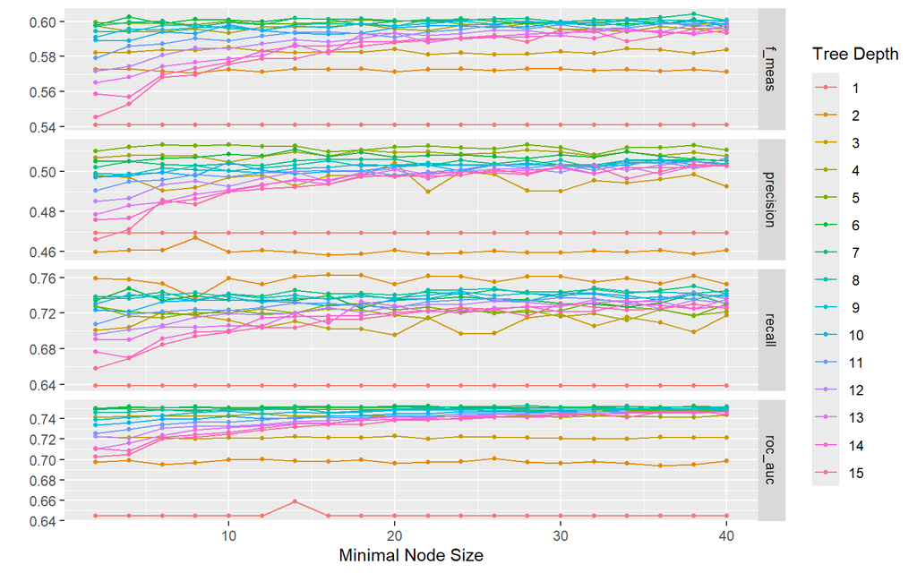

```r
autoplot(tree_rs)
```

Seleccionamos el mejor modelo en función del área bajo la curva ROC, y finalizamos el pipeline.

```r
best_model <- select_best(tree_rs, metric = "roc_auc")

final_model <- finalize_model(tree_spec, best_model)
```

## Fit y exploración

Fiteamos el modelo a nuestra muestra de entrenamiento.

```r
final_fit <- wf %>%
  update_model(final_model) %>%
  fit(train)
```

¿Qué variables aparecen en este modelo?

```r
final_fit
```

```
## ══ Workflow [trained] ══════════════════════════════════════════════════════════
## Preprocessor: Recipe
## Model: bag_tree()
##
## ── Preprocessor ────────────────────────────────────────────────────────────────
## 2 Recipe Steps
##
## • step_other()
## • step_downsample()
##
## ── Model ───────────────────────────────────────────────────────────────────────
## Bagged CART (classification with 25 members)
##
## Variable importance scores include:
##
## # A tibble: 8 × 4
##   term                         value std.error  used
##   <chr>                        <dbl>     <dbl> <int>
## 1 SEXO_SEL                     300.       5.17    25
## 2 EDAD_SEL                     292.       6.10    25
## 3 BHCH04_SEL                   168.       8.23    25
## 4 CONDICION_ACTIVIDAD_AGRUPADA 146.       2.85    25
## 5 CANT_NODEMANDANTES_TOTAL     112.       2.64    25
## 6 BHDC_SEL                      78.8      3.22    25
## 7 NIVEL_EDUCATIVO_AGRUPADO      70.0      2.53    25
## 8 CANT_DEMANDANTES_TOTAL        42.8      2.65    25
```

## Evaluación

¿Cómo fue la performance final del set de validación?

```r
test_val <- final_fit %>%
  predict(test) %>%
  bind_cols(., test)

test_val <- predict(final_fit, test, type = "prob") %>%
  bind_cols(test_val, .)

class_metrics <- metric_set(precision, recall,
                       accuracy, f_meas)

roc_auc(test_val, truth = realiza_domest, ".pred_No realiza") %>%
  bind_rows(class_metrics(test_val, truth = realiza_domest, estimate = .pred_class))
```

```
## # A tibble: 5 × 3
##   .metric   .estimator .estimate
##   <chr>     <chr>          <dbl>
## 1 roc_auc   binary         0.777
## 2 precision binary         0.532
## 3 recall    binary         0.754
## 4 accuracy  binary         0.702
## 5 f_meas    binary         0.624
```